# P10 : Détectez des faux billets avec Python

Notre objectif sera d'appréhender les facteurs pouvant influencer détectez les billets, dans ce cas, nous allons utiliser une régression logistique.

L'objectif de la régression logistique est de modéliser, de classifier, une variable binaire prenant ses valeurs dans {0,1} en fonction de variables explicatives quantitatives (et potentiellement qualitatives). La régression logistique est une méthode de classification (supervisée) qui permet de traiter des cas cela: vrais ou faux .

```python
#Importez les données,on charge tout d'abord les librairies nécessaires pour réaliser ce TP :

%matplotlib inline

import pandas as pd
import numpy as np
import seaborn as sns
import matplotlib.pyplot as plt
from matplotlib import rc


from sklearn.linear_model import LinearRegression
from sklearn.linear_model import LogisticRegression
from sklearn.model_selection import train_test_split
from sklearn.metrics import r2_score
import statsmodels.api as sm
from matplotlib.ticker import AutoMinorLocator

from sklearn.preprocessing import StandardScaler

%matplotlib inline

import pandas as pd
import numpy as np
import seaborn as sns
import matplotlib.pyplot as plt
from matplotlib import rc


from sklearn.linear_model import LinearRegression
from sklearn.linear_model import LogisticRegression
from sklearn.model_selection import train_test_split
from sklearn.metrics import r2_score
import statsmodels.api as sm
from matplotlib.ticker import AutoMinorLocator

from sklearn.metrics import confusion_matrix

from sklearn import linear_model
from sklearn import metrics
from scipy import stats

from sklearn import datasets
from sklearn.tree import DecisionTreeClassifier
from sklearn.metrics import roc_curve, roc_auc_score



from sklearn import linear_model

from scipy import stats
from sklearn import datasets
from sklearn import svm


import statsmodels.formula.api as smf

import pandas as pd
import numpy as np
import seaborn as sns
import matplotlib.pyplot as plt
import statsmodels.api as sm
import statsmodels.formula.api as smf
from scipy.stats import t, shapiro
from statsmodels.stats.outliers_influence import variance_inflation_factor
import statsmodels
# On importe les librairies

import pandas as pd
import numpy as np
import seaborn as sns
import matplotlib.pyplot as plt
from matplotlib import rc

from functions import *

from sklearn import decomposition
from sklearn import preprocessing
from sklearn.model_selection import train_test_split



from pandas import Series,DataFrame
import seaborn as sns

import palettable


from sklearn import datasets

import pandas as pd
from functions import plot_dendrogram
from scipy.cluster.hierarchy import linkage, fcluster
from sklearn import preprocessing



# On importe les outils de dessin
import matplotlib.pyplot as plt
import matplotlib.patches as mpatches
from mpl_toolkits.mplot3d import Axes3D

# On importe seaborn
import seaborn as sns

# On précise que l'on souhaite voir les graphiques dans le notebook
%matplotlib inline

# On importe les scipy stats et statsmodels
import scipy.stats as st
import statsmodels.api as sm
import re
```

```python
# Chargement des données
billets=pd.read_excel(r'C:\Users\lulu\Downloads\billets.xlsx')
billets.info()
billets.head()
```

```
<class 'pandas.core.frame.DataFrame'>
RangeIndex: 1500 entries, 0 to 1499
Data columns (total 7 columns):
 #   Column        Non-Null Count  Dtype
---  ------        --------------  -----
 0   is_genuine    1500 non-null   bool
 1   diagonal      1500 non-null   float64
 2   height_left   1500 non-null   float64
 3   height_right  1500 non-null   float64
 4   margin_low    1463 non-null   float64
 5   margin_up     1500 non-null   float64
 6   length        1500 non-null   float64
dtypes: bool(1), float64(6)
memory usage: 71.9 KB
```

|  | is_genuine | diagonal | height_left | height_right | margin_low | margin_up | length |
| --- | --- | --- | --- | --- | --- | --- | --- |
| 0 | True | 171.81 | 104.86 | 104.95 | 4.52 | 2.89 | 112.83 |
| 1 | True | 171.46 | 103.36 | 103.66 | 3.77 | 2.99 | 113.09 |
| 2 | True | 172.69 | 104.48 | 103.50 | 4.40 | 2.94 | 113.16 |
| 3 | True | 171.36 | 103.91 | 103.94 | 3.62 | 3.01 | 113.51 |
| 4 | True | 171.73 | 104.28 | 103.46 | 4.04 | 3.48 | 112.54 |

On y trouve les 6 variables suivantes:'diagonal','height_left','height_right','margin_low','margin_up','length'

```python
# on va voir si il y a NAN
billets.isnull().any()
```

```
is_genuine      False
diagonal        False
height_left     False
height_right    False
margin_low       True
margin_up       False
length          False
dtype: bool
```

```python
billets.index
```

```
RangeIndex(start=0, stop=1500, step=1)
```

```python
df=billets
```

# PARTIE I -------- Le nettoyage et l'exploration des données

## On va remplacer NAN par méthod "Linear Regression "

Different ways to fill the missing values Mean/Median, Mode bfill,ffill interpolate replace

# Steps to Predicting the Missing Data:

Step 1: Separate the null values from the data frame (df) and create a variable “test data”

```python
test_data = df[df['margin_low'].isnull()]
```

```python
test_data.head()
test_data.info()
```

```
<class 'pandas.core.frame.DataFrame'>
Int64Index: 37 entries, 72 to 1438
Data columns (total 7 columns):
 #   Column        Non-Null Count  Dtype
---  ------        --------------  -----
 0   is_genuine    37 non-null     bool
 1   diagonal      37 non-null     float64
 2   height_left   37 non-null     float64
 3   height_right  37 non-null     float64
 4   margin_low    0 non-null      float64
 5   margin_up     37 non-null     float64
 6   length        37 non-null     float64
dtypes: bool(1), float64(6)
memory usage: 2.1 KB
```

```python
test_data.head()
```

|  | is_genuine | diagonal | height_left | height_right | margin_low | margin_up | length |
| --- | --- | --- | --- | --- | --- | --- | --- |
| 72 | True | 171.94 | 103.89 | 103.45 | NaN | 3.25 | 112.79 |
| 99 | True | 171.93 | 104.07 | 104.18 | NaN | 3.14 | 113.08 |
| 151 | True | 172.07 | 103.80 | 104.38 | NaN | 3.02 | 112.93 |
| 197 | True | 171.45 | 103.66 | 103.80 | NaN | 3.62 | 113.27 |
| 241 | True | 171.83 | 104.14 | 104.06 | NaN | 3.02 | 112.36 |

```python
test_data.drop('is_genuine',axis=1,inplace=True)
```

Step 2: Drop the null values from the data frame (df) and represent them as ‘train data”

```python
df.dropna(inplace=True)
```

```python
df.drop('is_genuine',axis=1,inplace=True)
```

Step 3: Create “x_train” & “y_train” from train data.

```python
x_train = df.drop('margin_low',axis=1)
x_train
```

|  | diagonal | height_left | height_right | margin_up | length |
| --- | --- | --- | --- | --- | --- |
| 0 | 171.81 | 104.86 | 104.95 | 2.89 | 112.83 |
| 1 | 171.46 | 103.36 | 103.66 | 2.99 | 113.09 |
| 2 | 172.69 | 104.48 | 103.50 | 2.94 | 113.16 |
| 3 | 171.36 | 103.91 | 103.94 | 3.01 | 113.51 |
| 4 | 171.73 | 104.28 | 103.46 | 3.48 | 112.54 |
| ... | ... | ... | ... | ... | ... |
| 1495 | 171.75 | 104.38 | 104.17 | 3.09 | 111.28 |
| 1496 | 172.19 | 104.63 | 104.44 | 3.37 | 110.97 |
| 1497 | 171.80 | 104.01 | 104.12 | 3.36 | 111.95 |
| 1498 | 172.06 | 104.28 | 104.06 | 3.46 | 112.25 |
| 1499 | 171.47 | 104.15 | 103.82 | 3.37 | 112.07 |

1463 rows × 5 columns

```python
y_train = df['margin_low']
y_train
```

```
0       4.52
1       3.77
2       4.40
3       3.62
4       4.04
        ...
1495    4.42
1496    5.27
1497    5.51
1498    5.17
1499    4.63
Name: margin_low, Length: 1463, dtype: float64
```

Step 4: Build the linear regression model

```python
lr = LinearRegression()
lr.fit(x_train, y_train)
```

```
LinearRegression()
```

```python
from sklearn.linear_model import LinearRegression
import statsmodels.api as sm



x_train = sm.add_constant(x_train)

model = sm.OLS(y_train.astype(float),x_train.astype(float))
fitted_model = model.fit()
fitted_model.summary()
```

OLS Regression Results

| Dep. Variable: | margin_low | R-squared: | 0.477 |
| --- | --- | --- | --- |
| Model: | OLS | Adj. R-squared: | 0.476 |
| Method: | Least Squares | F-statistic: | 266.1 |
| Date: | Fri, 15 Jul 2022 | Prob (F-statistic): | 2.60e-202 |
| Time: | 23:50:05 | Log-Likelihood: | -1001.3 |
| No. Observations: | 1463 | AIC: | 2015. |
| Df Residuals: | 1457 | BIC: | 2046. |
| Df Model: | 5 |  |  |
| Covariance Type: | nonrobust |  |  |

|  | coef | std err | t | P>\|t\| | [0.025 | 0.975] |
| --- | --- | --- | --- | --- | --- | --- |
| const | 22.9948 | 9.656 | 2.382 | 0.017 | 4.055 | 41.935 |
| diagonal | -0.1111 | 0.041 | -2.680 | 0.007 | -0.192 | -0.030 |
| height_left | 0.1841 | 0.045 | 4.113 | 0.000 | 0.096 | 0.272 |
| height_right | 0.2571 | 0.043 | 5.978 | 0.000 | 0.173 | 0.342 |
| margin_up | 0.2562 | 0.064 | 3.980 | 0.000 | 0.130 | 0.382 |
| length | -0.4091 | 0.018 | -22.627 | 0.000 | -0.445 | -0.374 |

| Omnibus: | 73.627 | Durbin-Watson: | 1.893 |
| --- | --- | --- | --- |
| Prob(Omnibus): | 0.000 | Jarque-Bera (JB): | 95.862 |
| Skew: | 0.482 | Prob(JB): | 1.53e-21 |
| Kurtosis: | 3.801 | Cond. No. | 1.94e+05 |

Notes:  
[1] Standard Errors assume that the covariance matrix of the errors is correctly specified.  
[2] The condition number is large, 1.94e+05. This might indicate that there are  
strong multicollinearity or other numerical problems.

R-squared is possibly the most important measurement produced by this summary. R-squared is the measurement of how much of the independent variable is explained by changes in our dependent variables. In percentage terms, 0.477 would mean our model explains 47.7% of the change in our ‘margin_low’ variable

The regression output example hows that the height_left and height_right , margin_up ,length,these predictor variables are statistically significant because their p-values equal 0.000.

Step 5: Create the x_test from test data

```python
x_test = test_data[['diagonal','height_left','height_right','margin_up','length']]
x_test.head()
```

|  | diagonal | height_left | height_right | margin_up | length |
| --- | --- | --- | --- | --- | --- |
| 72 | 171.94 | 103.89 | 103.45 | 3.25 | 112.79 |
| 99 | 171.93 | 104.07 | 104.18 | 3.14 | 113.08 |
| 151 | 172.07 | 103.80 | 104.38 | 3.02 | 112.93 |
| 197 | 171.45 | 103.66 | 103.80 | 3.62 | 113.27 |
| 241 | 171.83 | 104.14 | 104.06 | 3.02 | 112.36 |

Step 6: Apply the model on x_test of test data to make predictions. here, we have created a new variable ‘y_pred’.

```python
y_pred = lr.predict(x_test)
```

```python
y_pred
```

```
array([4.31852466, 4.39366755, 4.41045663, 4.31901423, 4.6506171 ,
       3.80330831, 4.17973608, 4.12744154, 4.13503418, 4.16053851,
       4.17742026, 3.76855378, 4.05876385, 4.29804709, 4.16060746,
       4.09406453, 4.43984627, 4.47065037, 4.34164322, 4.08041448,
       3.61430588, 4.37181147, 4.09362068, 4.24962896, 3.89374829,
       3.74633265, 4.23741481, 4.71053287, 4.13778022, 5.05027715,
       4.80214523, 5.067584  , 5.04756967, 4.77896717, 5.726993  ,
       5.18586214, 5.14004269])
```

Step 7: Finally, we replace the missing values with predicted values.

```python
# Rechargement des données
billets=pd.read_excel(r'C:\Users\lulu\Downloads\billets.xlsx')
billets.info()
billets.head()
```

```
<class 'pandas.core.frame.DataFrame'>
RangeIndex: 1500 entries, 0 to 1499
Data columns (total 7 columns):
 #   Column        Non-Null Count  Dtype
---  ------        --------------  -----
 0   is_genuine    1500 non-null   bool
 1   diagonal      1500 non-null   float64
 2   height_left   1500 non-null   float64
 3   height_right  1500 non-null   float64
 4   margin_low    1463 non-null   float64
 5   margin_up     1500 non-null   float64
 6   length        1500 non-null   float64
dtypes: bool(1), float64(6)
memory usage: 71.9 KB
```

|  | is_genuine | diagonal | height_left | height_right | margin_low | margin_up | length |
| --- | --- | --- | --- | --- | --- | --- | --- |
| 0 | True | 171.81 | 104.86 | 104.95 | 4.52 | 2.89 | 112.83 |
| 1 | True | 171.46 | 103.36 | 103.66 | 3.77 | 2.99 | 113.09 |
| 2 | True | 172.69 | 104.48 | 103.50 | 4.40 | 2.94 | 113.16 |
| 3 | True | 171.36 | 103.91 | 103.94 | 3.62 | 3.01 | 113.51 |
| 4 | True | 171.73 | 104.28 | 103.46 | 4.04 | 3.48 | 112.54 |

```python
billets.loc[billets.margin_low.isna(),'margin_low'] = y_pred
```

```python
billets.isnull().any()
```

```
is_genuine      False
diagonal        False
height_left     False
height_right    False
margin_low      False
margin_up       False
length          False
dtype: bool
```

```python
billets.info()
billets.head()
```

```
<class 'pandas.core.frame.DataFrame'>
RangeIndex: 1500 entries, 0 to 1499
Data columns (total 7 columns):
 #   Column        Non-Null Count  Dtype
---  ------        --------------  -----
 0   is_genuine    1500 non-null   bool
 1   diagonal      1500 non-null   float64
 2   height_left   1500 non-null   float64
 3   height_right  1500 non-null   float64
 4   margin_low    1500 non-null   float64
 5   margin_up     1500 non-null   float64
 6   length        1500 non-null   float64
dtypes: bool(1), float64(6)
memory usage: 71.9 KB
```

|  | is_genuine | diagonal | height_left | height_right | margin_low | margin_up | length |
| --- | --- | --- | --- | --- | --- | --- | --- |
| 0 | True | 171.81 | 104.86 | 104.95 | 4.52 | 2.89 | 112.83 |
| 1 | True | 171.46 | 103.36 | 103.66 | 3.77 | 2.99 | 113.09 |
| 2 | True | 172.69 | 104.48 | 103.50 | 4.40 | 2.94 | 113.16 |
| 3 | True | 171.36 | 103.91 | 103.94 | 3.62 | 3.01 | 113.51 |
| 4 | True | 171.73 | 104.28 | 103.46 | 4.04 | 3.48 | 112.54 |

# donnée final

Ces données contiennent les informations de 1500 billets de la forme rectagle. On y trouve des informations telles que :

'diagonal', 'height_left', 'height_right', 'margin_low', 'margin_up', 'length'

La variable 'is_genuine' est la variable qui indique si la billet vrais (1) ou faux (0).

# PARTIE II ------evaluation la régression linéaire multiple sur le jeu de données

# VIF Variance Inflation Factor(VIF)

VIF can detect multicollinearity, but it does not identify independent variables that are causing multicollinearity. Here, correlation analysis is useful for detecting highly correlated independent variables.

Detect "Multicollinearity" de mon model Linear Regression

```python
import statsmodels.api as sm
from statsmodels.stats.outliers_influence import variance_inflation_factor

X = billets[['diagonal','height_left','height_right','margin_low','margin_up','length']]   # independent variables
y = billets['is_genuine']   # dependent variables
X = sm.add_constant(X)
# fit the regression model
reg = sm.OLS(y, X).fit()
# get Variance Inflation Factor (VIF)
pd.DataFrame({'variables':X.columns[1:], 'VIF':[variance_inflation_factor(X.values, i+1) for i in range(len(X.columns[1:]))]})
```

|  | variables | VIF |
| --- | --- | --- |
| 0 | diagonal | 1.017905 |
| 1 | height_left | 1.158830 |
| 2 | height_right | 1.260474 |
| 3 | margin_low | 1.937066 |
| 4 | margin_up | 1.419218 |
| 5 | length | 2.142265 |

VIF value Diagnosis 1 Complete absence of multicollinearity 1-2 Absence of strong multicollinearity

> 2 Presence of moderate to strong multicollinearity

# Vérifier la colinéarité des variables

On importe les données, puis on utilise la commande lm pour régresser 'length' en fonction des autres variables de l'échantillon

```python
reg_multi = smf.ols('length~ diagonal+height_left+height_right+margin_low+margin_up',data=billets).fit()
```

```python
print(reg_multi.summary())
```

```
                            OLS Regression Results
==============================================================================
Dep. Variable:                 length   R-squared:                       0.533
Model:                            OLS   Adj. R-squared:                  0.532
Method:                 Least Squares   F-statistic:                     341.3
Date:                Fri, 15 Jul 2022   Prob (F-statistic):          4.13e-244
Time:                        23:50:49   Log-Likelihood:                -1352.3
No. Observations:                1500   AIC:                             2717.
Df Residuals:                    1494   BIC:                             2749.
Df Model:                           5
Covariance Type:            nonrobust
================================================================================
                   coef    std err          t      P>|t|      [0.025      0.975]
--------------------------------------------------------------------------------
Intercept      160.2474     11.137     14.389      0.000     138.402     182.093
diagonal         0.0807      0.051      1.583      0.114      -0.019       0.181
height_left     -0.2357      0.055     -4.277      0.000      -0.344      -0.128
height_right    -0.2985      0.053     -5.673      0.000      -0.402      -0.195
margin_low      -0.6475      0.028    -23.203      0.000      -0.702      -0.593
margin_up       -0.9500      0.075    -12.605      0.000      -1.098      -0.802
==============================================================================
Omnibus:                       33.887   Durbin-Watson:                   1.837
Prob(Omnibus):                  0.000   Jarque-Bera (JB):               39.322
Skew:                          -0.309   Prob(JB):                     2.89e-09
Kurtosis:                       3.498   Cond. No.                     1.63e+05
==============================================================================

Notes:
[1] Standard Errors assume that the covariance matrix of the errors is correctly specified.
[2] The condition number is large, 1.63e+05. This might indicate that there are
strong multicollinearity or other numerical problems.
```

On constate ici que certains paramètres ne sont pas significativement différents de 0, car leur p-valeur n'est pas inférieure à 5 %, le niveau de test que nous souhaitons.

Le 𝑅2 vaut environ 0.533, et le 𝑅2 ajusté est d'environ 0.532.

vérifier est l'éventuelle colinéarité approchée des variables :

```python
variables = reg_multi.model.exog
[variance_inflation_factor(variables, i) for i in np.arange(1,variables.shape[1])]
```

```
[1.01619947913013,
 1.1448144664128137,
 1.2338955982279236,
 1.4239239932099566,
 1.2828031310624293]
```

Ici, tous les coefficients sont inférieurs à 10, il n'y a donc pas de problème de colinéarité.

# Testez l’homoscédasticité

On peut également tester l’homoscédasticité (c'est-à-dire la constance de la variance) des résidus

```python
_, pval, __, f_pval = statsmodels.stats.diagnostic.het_breuschpagan(reg_multi.resid, variables)
print('p value test Breusch Pagan:', pval)
```

```
p value test Breusch Pagan: 9.11710733794065e-18
```

La p-valeur ici est inférieure à $5$%, on rejette l'hypothèse $H0$ selon laquelle les variances sont constantes (l'hypothèse d’homoscédasticité).

# Testez la normalité des résidus

Si l'on veut tester la normalité des résidus, on peut faire un test de Shapiro-Wilk

```python
shapiro(reg_multi.resid)
```

```
ShapiroResult(statistic=0.9923569560050964, pvalue=5.092289825370244e-07)
```

# PARTIE II ------ analyse descriptive des données

```python
# Résumé des données brutes
billets.describe()
```

|  | diagonal | height_left | height_right | margin_low | margin_up | length |
| --- | --- | --- | --- | --- | --- | --- |
| count | 1500.000000 | 1500.000000 | 1500.000000 | 1500.000000 | 1500.000000 | 1500.00000 |
| mean | 171.958440 | 104.029533 | 103.920307 | 4.483475 | 3.151473 | 112.67850 |
| std | 0.305195 | 0.299462 | 0.325627 | 0.659632 | 0.231813 | 0.87273 |
| min | 171.040000 | 103.140000 | 102.820000 | 2.980000 | 2.270000 | 109.49000 |
| 25% | 171.750000 | 103.820000 | 103.710000 | 4.020000 | 2.990000 | 112.03000 |
| 50% | 171.960000 | 104.040000 | 103.920000 | 4.310000 | 3.140000 | 112.96000 |
| 75% | 172.170000 | 104.230000 | 104.150000 | 4.870000 | 3.310000 | 113.34000 |
| max | 173.010000 | 104.880000 | 104.950000 | 6.900000 | 3.910000 | 114.44000 |

```python
df_describe = billets.describe().T
print(df_describe)
```

```
               count        mean       std     min     25%     50%     75%  \
diagonal      1500.0  171.958440  0.305195  171.04  171.75  171.96  172.17
height_left   1500.0  104.029533  0.299462  103.14  103.82  104.04  104.23
height_right  1500.0  103.920307  0.325627  102.82  103.71  103.92  104.15
margin_low    1500.0    4.483475  0.659632    2.98    4.02    4.31    4.87
margin_up     1500.0    3.151473  0.231813    2.27    2.99    3.14    3.31
length        1500.0  112.678500  0.872730  109.49  112.03  112.96  113.34

                 max
diagonal      173.01
height_left   104.88
height_right  104.95
margin_low      6.90
margin_up       3.91
length        114.44
```

```python
billets['is_genuine'].value_counts()
```

```
True     1000
False     500
Name: is_genuine, dtype: int64
```

Il y 1000 billets varis et 500 billets faux

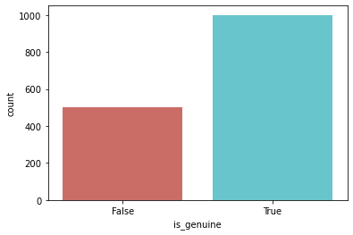

```python
sns.countplot(x='is_genuine',data=billets,palette='hls')
plt.show()
plt.savefig('count_plot')
```

# Analyses multivariables et visualisez

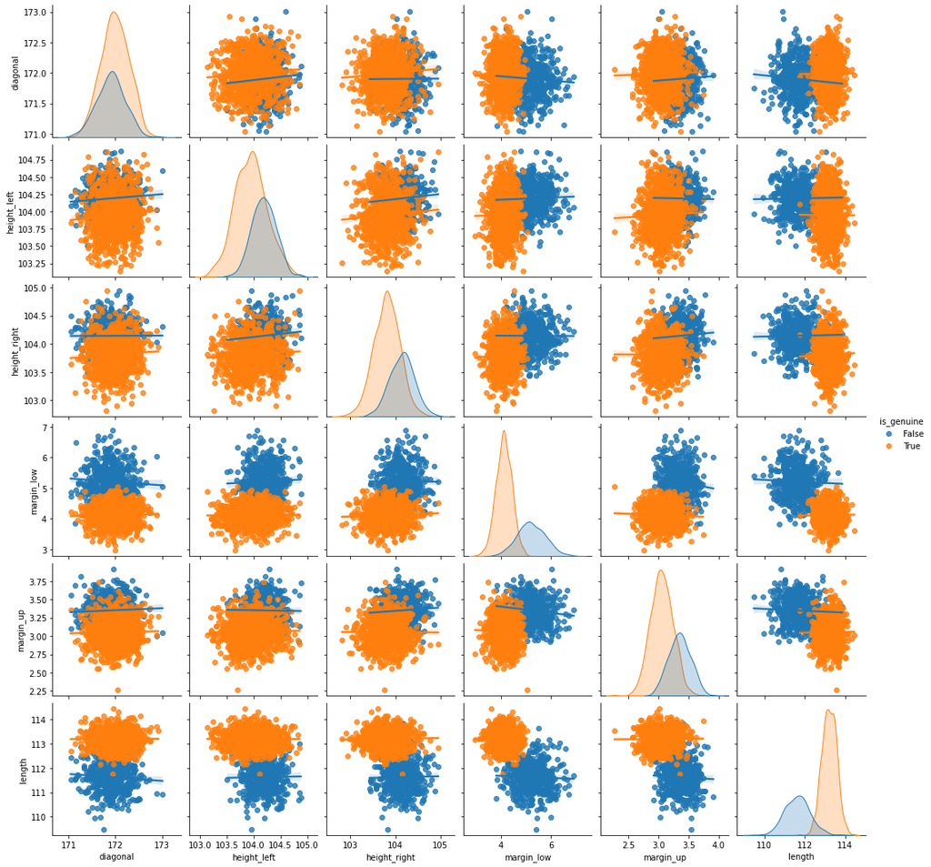

```python
sns.pairplot(billets,hue='is_genuine',vars=['diagonal','height_left','height_right','margin_low','margin_up','length'],kind='reg',diag_kind='kde')
plt.show()
```

Les modèles statistiques permettent d’obtenir des petits p. Ils ont un intérêt supplémentaire non négligeable : ils permettent de mesurer à quel point un facteur agit sur la variable d’intérêt. Ces mesures d’association sont :

Les Odds Ratio pour les régressions logistiques

La p-value renseigne sur la significativité statistique, les mesures d’association quantifient le lien entre deux variables.

# Visualisez le nuage de points

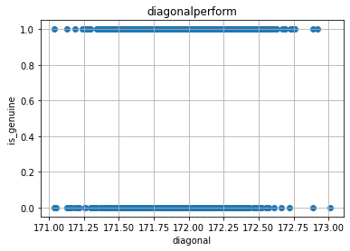

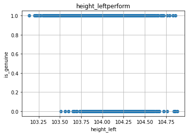

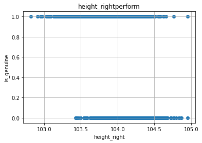

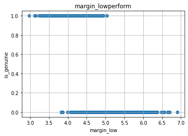

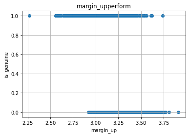

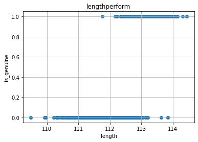

```python
#definition function
def drawing(x,y,xlabel):
    plt.scatter(x,y)
    plt.title('%sperform' %xlabel)
    plt.xlabel(xlabel)
    plt.ylabel('is_genuine')
    plt.grid()
    plt.show()
#draw
drawing(billets['diagonal'],billets['is_genuine'],'diagonal')
drawing(billets['height_left'],billets['is_genuine'],'height_left')
drawing(billets['height_right'],billets['is_genuine'],'height_right')
drawing(billets['margin_low'],billets['is_genuine'],'margin_low')
drawing(billets['margin_up'],billets['is_genuine'],'margin_up')
drawing(billets['length'],billets['is_genuine'],'length')
```

# PARTIE III ------Recherchez une bonne partition

Les algorithmes de clustering permettent de partitionner un jeu de données en sous-groupes d'observations similaires ;

Ils peuvent être utilisés pour

mieux comprendre les données ;

faciliter la visualisation des données ;

inférer des propriétés des données.

```python
billets.columns
```

```
Index(['is_genuine', 'diagonal', 'height_left', 'height_right', 'margin_low',
       'margin_up', 'length'],
      dtype='object')
```

```python
 billets.values
```

```
array([[True, 171.81, 104.86, ..., 4.52, 2.89, 112.83],
       [True, 171.46, 103.36, ..., 3.77, 2.99, 113.09],
       [True, 172.69, 104.48, ..., 4.4, 2.94, 113.16],
       ...,
       [False, 171.8, 104.01, ..., 5.51, 3.36, 111.95],
       [False, 172.06, 104.28, ..., 5.17, 3.46, 112.25],
       [False, 171.47, 104.15, ..., 4.63, 3.37, 112.07]], dtype=object)
```

```python
billets.index
```

```
RangeIndex(start=0, stop=1500, step=1)
```

```python
data=billets[['diagonal', 'height_left', 'height_right', 'margin_low',
       'margin_up', 'length']]
```

```python
data
```

|  | diagonal | height_left | height_right | margin_low | margin_up | length |
| --- | --- | --- | --- | --- | --- | --- |
| 0 | 171.81 | 104.86 | 104.95 | 4.52 | 2.89 | 112.83 |
| 1 | 171.46 | 103.36 | 103.66 | 3.77 | 2.99 | 113.09 |
| 2 | 172.69 | 104.48 | 103.50 | 4.40 | 2.94 | 113.16 |
| 3 | 171.36 | 103.91 | 103.94 | 3.62 | 3.01 | 113.51 |
| 4 | 171.73 | 104.28 | 103.46 | 4.04 | 3.48 | 112.54 |
| ... | ... | ... | ... | ... | ... | ... |
| 1495 | 171.75 | 104.38 | 104.17 | 4.42 | 3.09 | 111.28 |
| 1496 | 172.19 | 104.63 | 104.44 | 5.27 | 3.37 | 110.97 |
| 1497 | 171.80 | 104.01 | 104.12 | 5.51 | 3.36 | 111.95 |
| 1498 | 172.06 | 104.28 | 104.06 | 5.17 | 3.46 | 112.25 |
| 1499 | 171.47 | 104.15 | 103.82 | 4.63 | 3.37 | 112.07 |

1500 rows × 6 columns

# I Partitionnez les données avec un algorithme de clustering hiérarchique

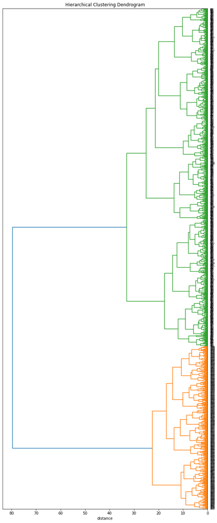

```python
import pandas as pd
from functions import plot_dendrogram
from scipy.cluster.hierarchy import linkage, fcluster
from sklearn import preprocessing



# préparation des données pour le clustering
X = data.values
names = data.index

# Centrage et Réduction
std_scale = preprocessing.StandardScaler().fit(X)
X_scaled = std_scale.transform(X)

# Clustering hiérarchique
Z = linkage(X_scaled, 'ward')

# Affichage du dendrogramme
plot_dendrogram(Z, names)
```

# II Partitionnez les données avec l’algorithme du k-means

```python
import numpy as np
import pandas as pd
from matplotlib import pyplot as plt
from sklearn.datasets import make_blobs

# Import the kmeans algorithm
from sklearn.cluster import KMeans

# Import the sklearn function
from sklearn.preprocessing import StandardScaler
```

```python
# Standardize the data

scaler = StandardScaler()
df_scaled = scaler.fit_transform(data)
df_scaled
```

```
array([[-0.48653957,  2.77412327,  3.16324041,  0.0553898 , -1.128325  ,
         0.17365114],
       [-1.63372936, -2.23653528, -0.79966777, -1.08198744, -0.69679916,
         0.47166629],
       [ 2.3978233 ,  1.50475644, -1.29119126, -0.12659056, -0.91256208,
         0.55190114],
       ...,
       [-0.51931643, -0.06524991,  0.61346228,  1.55672775,  0.89984645,
        -0.83501554],
       [ 0.3328817 ,  0.83666863,  0.42914097,  1.04111674,  1.33137229,
        -0.4911519 ],
       [-1.6009525 ,  0.40241156, -0.30814427,  0.22220513,  0.94299904,
        -0.69747008]])
```

```python
# Creation un k-means clustering model
kmeans = KMeans(init='random', n_clusters=2, n_init=10)

# mettre le data dans the model
kmeans.fit(df_scaled)

# Determiner  le data point de quel cluster :
clusters = kmeans.predict(df_scaled)
```

```python
# Ajouter les number cluster pour the original data
df_scaled_clustered = pd.DataFrame(df_scaled, columns=data.columns, index=data.index)
df_scaled_clustered['cluster'] = clusters

df_scaled_clustered.head()
```

|  | diagonal | height_left | height_right | margin_low | margin_up | length | cluster |
| --- | --- | --- | --- | --- | --- | --- | --- |
| 0 | -0.486540 | 2.774123 | 3.163240 | 0.055390 | -1.128325 | 0.173651 | 1 |
| 1 | -1.633729 | -2.236535 | -0.799668 | -1.081987 | -0.696799 | 0.471666 | 0 |
| 2 | 2.397823 | 1.504756 | -1.291191 | -0.126591 | -0.912562 | 0.551901 | 0 |
| 3 | -1.961498 | -0.399294 | 0.060498 | -1.309463 | -0.610494 | 0.953075 | 0 |
| 4 | -0.748754 | 0.836669 | -1.414072 | -0.672532 | 1.417677 | -0.158750 | 0 |

```python
from sklearn.decomposition import PCA

# Create a PCA model to reduce our data to 2 dimensions for visualisation
pca = PCA(n_components=2)
pca.fit(df_scaled)

# Transfor the scaled data to the new PCA space
df_reduced = pca.transform(df_scaled)
```

```python
# devenir un dataframe
df_reduceddf = pd.DataFrame(df_reduced, index=data.index, columns=['PC1','PC2'])
df_reduceddf['cluster'] = clusters
df_reduceddf.head()
```

|  | PC1 | PC2 | cluster |
| --- | --- | --- | --- |
| 0 | 1.644135 | 0.747843 | 1 |
| 1 | -2.019910 | -2.207492 | 0 |
| 2 | -0.969864 | 2.620492 | 0 |
| 3 | -1.377462 | -1.818370 | 0 |
| 4 | 0.148712 | -0.566722 | 0 |

# Visualation les Clusters

```
[[-1.02078618e+00  3.64678500e-02 -3.38618023e-15]
 [ 2.06626881e+00 -7.38179867e-02  1.00000000e+00]]
```

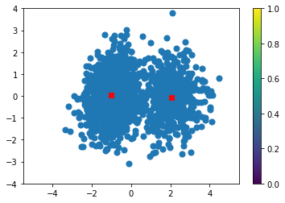

```python
kmeans = KMeans(n_clusters=2).fit(df_reduceddf)
centroids = kmeans.cluster_centers_
print(centroids)

plt.scatter(df_reduceddf['PC1'],df_reduceddf['PC2'],s=50)

plt.scatter(centroids[:, 0], centroids[:, 1], c='red', s=50,marker='X')



plt.xlim([-5.5, 5.5])
plt.ylim([-4, 4])
plt.colorbar()

plt.show()
```